# Non-Diagonal Case

Carl James Schwarz

2021-10-24

# 1 Location of vignette source and code.

Because of the length of time needed to run the vignettes, only static vignettes have been included with this package.

The original of the vignettes and the code can be obtained from the GitHub site at https://github.com/cschwarz-stat-sfu-ca/BTSPAS

# 2 Introduction

This case represents a generalization of the diagonal case considered in a separate vignette. Now, rather than assuming that all recaptures from a release take place in a single recovery stratum, recoveries could take place over multiple recovery strata.

Again, consider an experiment to estimate the number of outgoing smolts on a small river. The run of smolts extends over several weeks. As smolts migrate, they are captured and marked with individually numbered tags and released at the first capture location using, for example, a fishwheel. The migration continues, and a second fishwheel takes a second sample several kilometers down stream. At the second fishwheel, the captures consist of a mixture of marked (from the first fishwheel) and unmarked fish.

The efficiency of the fishwheels varies over time in response to stream flow, run size passing the wheel and other uncontrollable events. So it is unlikely that the capture probabilities are equal over time at either location, i.e. are heterogeneous over time.

We suppose that we can temporally stratify the data into, for example, weeks, where the capture-probabilities are (mostly) homogeneous at each wheel in each week.

But now, we allow tagged animals to be captured in several recovery strata. For example, suppose that in each julian week $j$, $n1[j]$ fish are marked and released above the rotary screw trap. Of these, $m2[j,j]$ are recaptured in julian week $j$; $m2[j,j+1]$ are recaptured in julian week $j+1$; $m2[j,j+2]$ are recaptured in julian week $j+2$ and so on.

At the same time, $u2[j]$ unmarked fish are captured at the screw trap.

This implies that the data can be structured as a **non-diagonal** array similar to:

```
Recovery Stratum
               tagged    rs1      rs2     rs3 ...rs4                 rsk  rs(k+1)
Marking   ms1    n1[1]  m2[1,1] m2[1,2] m2[1,3] m2[1,4]      0  ...   0      0
Stratum   ms2    n1[2]   0      m2[2,2] m2[2,3] m2[2,4] .... 0  ...   0      0
          ms3    n1[3]   0       0      m2[3,3] m2[3,4] ...  0  ...   0      0
          ...
          msk    n1[k]   0       0      0  ...  0            0    m2[k,k] m2[k,k+1]
Newly
Untagged               u2[1]   u2[2]   u2[3]  ...                 u2[k]   u2[k,k+1]
captured
```

Here the tagging and recapture events have been stratified in to $k$ temporal strata. Marked fish from one stratum tend to spread out and are recaptured over multiple strata. Several additional recovery strata are needed at the end of the experiment to fully capture the final release stratum.

Because the lower diagonal of the recovery matrix is zero, the data can be entered in a shorthand fashion by showing the recoveries in the same stratum as release, the next stratum, etc, up to a maximum number of recovery strata per release.

## 2.1 Fixing values of $p$ or using covariates.

Refer to the vignette on the *Diagonal Case* for information about fixing values of $p$ or modelling $p$ using covariates such a stream flow or smoothing $p$ using a temporal spline.

# 3 Example of basic non-diagonal BTSPAS fit.

## 3.1 Reading in the data

Here is an example of some raw data that is read in:

```r
demo.data.csv <- textConnection(
"Date        ,     n1  , X0  , X1  , X2  , X3  , X4
 1987-04-26  ,      8  ,  0  ,  0  ,  0  ,  0  ,  2
 1987-04-27  ,      5  ,  0  ,  0  ,  0  ,  0  ,  0
 1987-04-28  ,      6  ,  0  ,  0  ,  0  ,  0  ,  0
 1987-04-29  ,     17  ,  0  ,  0  ,  2  ,  1  ,  1
 1987-04-30  ,     66  ,  0  ,  1  ,  0  ,  2  ,  3
 1987-05-01  ,    193  ,  0  ,  1  ,  7  ,  7  ,  2
 1987-05-02  ,     90  ,  0  ,  2  ,  0  ,  0  ,  0
 1987-05-03  ,    260  ,  0  ,  0  , 14  ,  6  ,  1
 1987-05-04  ,    368  ,  0  ,  9  , 46  ,  4  ,  2
 1987-05-05  ,    506  ,  0  , 38  , 33  , 11  ,  0
 1987-05-06  ,    317  ,  1  , 27  , 26  ,  3  ,  1
 1987-05-07  ,     43  ,  0  ,  4  ,  3  ,  0  ,  2
 1987-05-08  ,    259  ,  1  , 42  ,  5  ,  2  ,  0
 1987-05-09  ,    259  ,  1  , 32  , 27  ,  1  ,  0
 1987-05-10  ,    249  ,  1  , 85  ,  3  ,  1  ,  0
 1987-05-11  ,    250  ,  3  , 21  , 19  ,  2  ,  0
 1987-05-12  ,    298  , 42  , 16  , 11  ,  9  ,  1
 1987-05-13  ,    250  ,  1  ,  7 ,  25  ,  6  ,  4
 1987-05-14  ,    193  ,  0  ,  9 ,  18  ,  8  ,  0
 1987-05-15  ,    207  ,  0  , 17  , 21  ,  2  ,  0
 1987-05-16  ,    175  ,  0  , 18  , 10  ,  1  ,  0
 1987-05-17  ,    141  ,  0  , 12  , 14  ,  7  ,  1
 1987-05-18  ,    155  ,  0  ,  1  , 19  , 13  ,  6
 1987-05-19  ,    123  ,  0  ,  5  , 22  ,  5  ,  0
 1987-05-20  ,    128  ,  0  ,  6  , 17  ,  2  ,  1
 1987-05-21  ,     72  ,  0  , 11  ,  9  ,  2  ,  0
 1987-05-22  ,     57  ,  0  ,  6  ,  8  ,  0  ,  1
 1987-05-23  ,     49  ,  0  ,  4  ,  2  ,  1  ,  0
 1987-05-24  ,     57,   14  ,  2  ,  1  ,  0  ,  0
 1987-05-25  ,     18  ,  0  ,  3  ,  0  ,  0  ,  0
 1987-05-26  ,     20  ,  0  ,  3  ,  4  ,  0  ,  0
 1987-05-27  ,     16  ,  0  ,  3  ,  0  ,  0  ,  0
 1987-05-28  ,     15  ,  0  ,  0  ,  2  ,  0  ,  0
 1987-05-29  ,     10  ,  0  ,  1  ,  0  ,  1  ,  0
 1987-05-30  ,     13  ,  0  ,  0  ,  2  ,  0  ,  0
 1987-05-31  ,      8  ,  0  ,  3  ,  1  ,  0  ,  0
 1987-06-01  ,      2  ,  0  ,  1  ,  0  ,  0  ,  0
 1987-06-02  ,     23  ,  0  ,  6  ,  0  ,  0  ,  0
 1987-06-03  ,     20  ,  0  ,  2  ,  0  ,  0  ,  0
 1987-06-04  ,     10  ,  0  ,  4  ,  1  ,  0  ,  0
 1987-06-05  ,     10  ,  3  ,  1  ,  0  ,  0  ,  0
 1987-06-06  ,      5  ,  0  ,  2  ,  0  ,  0  ,  1
 1987-06-07  ,      2  ,  0  ,  0  ,  0  ,  0  ,  0
 1987-06-08  ,      2  ,  0  ,  1  ,  0  ,  0  ,  0  ")

demo.data <- read.csv(demo.data.csv, header=TRUE, as.is=TRUE, strip.white=TRUE)

print(demo.data)
```

```
#>          Date  n1 X0 X1 X2 X3 X4
#> 1  1987-04-26   8  0  0  0  0  2
#> 2  1987-04-27   5  0  0  0  0  0
#> 3  1987-04-28   6  0  0  0  0  0
#> 4  1987-04-29  17  0  0  2  1  1
#> 5  1987-04-30  66  0  1  0  2  3
#> 6  1987-05-01 193  0  1  7  7  2
#> 7  1987-05-02  90  0  2  0  0  0
#> 8  1987-05-03 260  0  0 14  6  1
#> 9  1987-05-04 368  0  9 46  4  2
#> 10 1987-05-05 506  0 38 33 11  0
#> 11 1987-05-06 317  1 27 26  3  1
#> 12 1987-05-07  43  0  4  3  0  2
#> 13 1987-05-08 259  1 42  5  2  0
#> 14 1987-05-09 259  1 32 27  1  0
```

[output cut: 30 more lines]

```r
demo.data$Date <- as.Date(demo.data$Date, "%Y-%m-%d")
demo.data$jday <- as.numeric(format(demo.data$Date, "%j"))
```

In the first release stratum, a total of 8 fish were tagged and released. No recoveries occurred until 4 days later.

Because the recoveries take place in more strata than releases, the $u2$ vector is read in separately. Note that is must be sufficiently long to account for the number of releases plus potential movement, for a length of 48:

```r
demo.data.u2 <- c(0  ,    2  ,    1  ,  2 ,   39 , 226  , 75 , 129 , 120 , 380 ,
                  921, 1005  , 1181 ,1087 , 1108 ,1685  ,671 ,1766 , 636 , 483 ,
                  170,  269  ,  212 , 260 ,  154 , 145  , 99 ,  58 ,  74 ,  40 ,
                   50,   59  ,   40 ,   9 ,   14 ,  13  , 22 ,  24 ,  33 ,  19 ,
                   12,    7  ,    4 ,   0 ,    0 ,  59  ,  0 ,   0 )
```

We also separate out the recoveries $m2$ into a matrix

```r
demo.data.m2 <- as.matrix(demo.data[,c("X0","X1","X2","X3","X4")])
```

## 3.2 Preliminary screening of the data

A pooled-Petersen estimator would add all of the marked, recaptured and unmarked fish to give an estimate of 73,385.

Let us look at the data in more detail:

- In many of the release strata, there are small number of fish tagged and released.
- Most the recoveries occur soon after release, but there is longer right tail.
- It is difficult to estimate capture efficiency directly because of the smearing of releases over multiple recovery strata.

Let us look at the pattern of unmarked fish captured at the second trap:

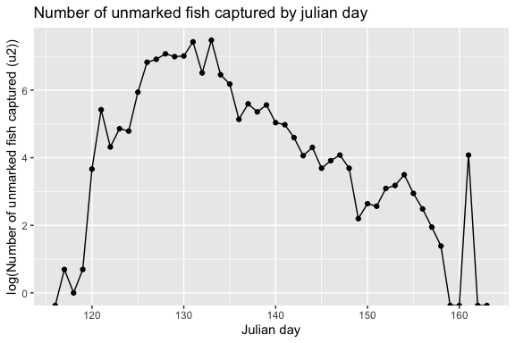

Observed number of unmarked recaptures

There appears to be a gradual rise and fall in the number of unmarked fish with no sudden jumps. Something funny appears to have happened around julian day 160 – I suspect that some pooling of data has occurred here.

*BTSPAS* provides two fitting routine: